# Data Wrangling

Retrieve and process the survey’s data.

Hauke Roggenkamp https://github.com/Howquez (CLICCS)https://www.cliccs.uni-hamburg.de/  
2021-05-25

```r
knitr::opts_chunk$set(echo = FALSE)

library(data.table)
library(kableExtra)
library(downloadthis)
library(stringr)
library(lubridate)
library(magrittr)
library(tidyverse)
library(wesanderson)
library(glue)
library(gridExtra)
library(patchwork)
library(sjPlot)
```

```r
layout <- theme(panel.background = element_rect(fill = "white"),
                panel.grid = element_blank(),
                panel.grid.major.y = element_line(colour="gray", size=0.25),
                legend.key = element_rect(fill = "white"),
                axis.line.x.bottom = element_line(size = 0.25),
                axis.line.y.left = element_line(size = 0.25),
                plot.margin = unit(c(1,1,1,1), "cm"),
                legend.title = element_blank()
)
```

# Load & subset data

```r
# read data
DT <- read.csv(file="../data/pilot/all_apps_wide_2021-05-25.csv",
               stringsAsFactors = FALSE) %>% data.table()

if(knitr::is_html_output()){
  DT %>%
    download_this(
          output_name = "rawData",
          output_extension = ".csv", # CSV output
          button_label = "Download raw data",
          button_type = "default",
        )
}
```

Because most of the variables are secondary, I subset the data we are most interested in, that is, the variables needed to identify subjects (IDs) as well as the variables needed to calculate Baillon et al. (2018)’s indices. To conduct analyses with covariates and treatment information, one can use the IDs and merge the data.

```r
# select relevant columns for main- and control variables separately
mainRegex <- "^participant\\.code$|matching_probability$|event_decision$|Comprehension$"
mainVariables <- str_subset(string = names(DT),
                            pattern = mainRegex)

mt <- DT[participant._index_in_pages > 0,# Outro.1.player.Comprehension != "no",
         ..mainVariables] #"mt" for Main Table (in contrast to "Control Table" oder "Data Table")

attrition <- round(1 - NROW(DT[participant._index_in_pages == 20]) / NROW(DT[participant._index_in_pages > 0]), digits = 3)*100
```

Importantly, the data contains all (N= 233) observations that *started* the survey (`participant._index_in_pages > 0`). Not all of them (only 119) finished the survey. In fact, 48.9% started but did not finish the survey.[^1]

# Rename data

To make the variables a little more readable, I’ll remove the `.player` substring.[^2]

```r
oldNames <- names(mt)
newNames <- str_replace_all(string=oldNames,
                            pattern="\\.player",
                            replacement="")
setnames(x=mt,
         old=oldNames,
         new=newNames)
```

# Prepare indices

This step is not necessary and needs to be adjusted as soon as we become interested in the events itself. But for the time being, I replace the event values to `composite` or `single`. This is fairly simple, because the longer event strings indicate that the subject had to bet on composite events. As a consequence, replacing the values is a matter of counting characters.

```r
for(round in 1:12){

  col = glue("Uncertainty.{round}.event_decision")

  set(x = mt,
      i = which(mt[[col]] %>% as.character() %>% nchar() > 2),
      j = col,
      value = "composite")

  set(x = mt,
      i = which(mt[[col]] %>% as.character() %>% nchar() == 2),
      j = col,
      value = "single")
}
```

# Calculate indices

This process is a little messy. To calculate the indices, we need to differentiate between composite and single events and calculate compound-event probabilities (CEPs) as well as single-event probabilities (SEPs) and their means for each observation. Having done so, one can calculate Baillon et al’s *ambiguity aversion index* (called AAI) as well as the *ambiguity-generated insensitivity (a-insensitivity) index* (called AGII) which are defined as follows:

$$\begin{align}
\text{AAI}&=1-\overline{m_c} - \overline{m_s} \\
\text{AGII}&=3 \times \bigg(\frac{1}{3}- (\overline{m_c} - \overline{m_s})\bigg)
\end{align}$$
Where the bar indicates the average of single ($s$) or ($c$) composite events. As a consequence $\overline{m_{s,c}}$ represents the `ASEP` or `ACEP` in the code chunk below.

The subjects played the Baillon-tasks twice in the same order of events. Due to laziness, the calculation of the two sets of indices (one pre- and one post-treatment) lacks elegance and is done in two code chunks.[^3] The pre-treatment indices are calculated as follows:

```r
#..calculate Baillons Indices
for(row in 1:NROW(mt)){

  #..first get a vector of event types
  vector = c()
  for(round in 1:6){
    col = glue("Uncertainty.{round}.event_decision")
    vector = append(vector, mt[row, get(col)])
  }

  # consider composite events first and get the round numbers where composite events were shown
  cEvents = str_which(string = vector,
                       pattern = "composite")
  # now loop over these rounds to add the respective matching_probabilities
  CEPs = NULL # Compound-Event Probabilities
  for(compositeRound in cEvents){
    col <- glue("Uncertainty.{compositeRound}.matching_probability")
    increment <- mt[row, get(col)]
    CEPs <- append(CEPs, increment)
  }
  # average
  ACEP = mean(CEPs, na.rm=TRUE)/100

  # do the same for single events
  sEvents <- str_which(string = vector,
                       pattern = "single")
  SEPs = NULL
  for(singleRound in sEvents){
    col <- glue("Uncertainty.{singleRound}.matching_probability")
    increment <- mt[row, get(col)]
    SEPs <- append(SEPs, increment)
  }
  ASEP = mean(SEPs, na.rm=TRUE)/100

  # calculate Ambiguity Aversion Index (AAI)
  AAI = 1 - ACEP - ASEP

  # calculate  ambiguity-generated insensitivity (a-insensitivity) index (AGII)
  AGII = 3 * (1/3 - (ACEP - ASEP))

  # write averages
  mt[row,
     pre_ASEP := ASEP]
  mt[row,
     pre_ACEP := ACEP]
  # write indices
  mt[row,
     pre_AAI := AAI]
  mt[row,
     pre_AGII := AGII]
}
```

The post-treatment indices’ calculation follows the same rules but adds a `+6` to the event vectors. This is ugly but feasible because the sequence of events in the first 6 rounds is exactly the same as in rounds 7-12.

```r
#..calculate Baillons Indices
for(row in 1:NROW(mt)){

  #..first get a vector of event types
  vector = c()
  for(round in 1:6){
    col = glue("Uncertainty.{round}.event_decision")
    vector = append(vector, mt[row, get(col)])
  }

  # consider composite events first and get the round numbers where composite events were shown
  cEvents = str_which(string = vector,
                       pattern = "composite") + 6
  # now loop over these rounds to add the respective matching_probabilities
  CEPs = NULL # Compound-Event Probabilities
  for(compositeRound in cEvents){
    col <- glue("Uncertainty.{compositeRound}.matching_probability")
    increment <- mt[row, get(col)]
    CEPs <- append(CEPs, increment)
  }
  # average
  ACEP = mean(CEPs, na.rm=TRUE)/100

  # do the same for single events
  sEvents <- str_which(string = vector,
                       pattern = "single") + 6
  SEPs = NULL
  for(singleRound in sEvents){
    col <- glue("Uncertainty.{singleRound}.matching_probability")
    increment <- mt[row, get(col)]
    SEPs <- append(SEPs, increment)
  }
  ASEP = mean(SEPs, na.rm=TRUE)/100

  # calculate Ambiguity Aversion Index (AAI)
  AAI = 1 - ACEP - ASEP

  # calculate  ambiguity-generated insensitivity (a-insensitivity) index (AGII)
  AGII = 3 * (1/3 - (ACEP - ASEP))

  # write averages
  mt[row,
     post_ASEP := ASEP]
  mt[row,
     post_ACEP := ACEP]

  # write indices
  mt[row,
     post_AAI := AAI]
  mt[row,
     post_AGII := AGII]
}
```

Having done that, the data looks as follows.

```r
mt %>%
  head(n = 10) %>%
  kbl() %>%
  scroll_box(width="120%") %>%
  kable_paper("hover",
              full_width = TRUE,
              fixed_thead = TRUE)
```

| participant.code | Uncertainty.1.matching_probability | Uncertainty.1.event_decision | Uncertainty.2.matching_probability | Uncertainty.2.event_decision | Uncertainty.3.matching_probability | Uncertainty.3.event_decision | Uncertainty.4.matching_probability | Uncertainty.4.event_decision | Uncertainty.5.matching_probability | Uncertainty.5.event_decision | Uncertainty.6.matching_probability | Uncertainty.6.event_decision | Uncertainty.7.matching_probability | Uncertainty.7.event_decision | Uncertainty.8.matching_probability | Uncertainty.8.event_decision | Uncertainty.9.matching_probability | Uncertainty.9.event_decision | Uncertainty.10.matching_probability | Uncertainty.10.event_decision | Uncertainty.11.matching_probability | Uncertainty.11.event_decision | Uncertainty.12.matching_probability | Uncertainty.12.event_decision | Outro.1.Comprehension | pre_ASEP | pre_ACEP | pre_AAI | pre_AGII | … |
| --- | --- | --- | --- | --- | --- | --- | --- | --- | --- | --- | --- | --- | --- | --- | --- | --- | --- | --- | --- | --- | --- | --- | --- | --- | --- | --- | --- | --- | --- | --- |
| 17ogiqcy | 25 | single | 60 | composite | 35 | single | 45 | composite | 75 | composite | 55 | single | 79 | single | 97 | composite | 3 | single | 82 | composite | 21 | composite | 18 | single | yes | 0.3833333 | 0.6000000 | 0.0166667 | 0.35 | … |
| 3mo3j6tk | NA | single | NA | composite | NA | composite | NA | single | NA | composite | NA | single | NA | single | NA | composite | NA | composite | NA | single | NA | composite | NA | single |  | NaN | NaN | NaN | NaN | … |
| if4h90kt | NA | single | NA | composite | NA | single | NA | single | NA | composite | NA | composite | NA | single | NA | composite | NA | single | NA | single | NA | composite | NA | composite |  | NaN | NaN | NaN | NaN | … |
| 030qxo6u | 65 | composite | 50 | composite | 20 | single | 25 | single | 58 | composite | 15 | single | 65 | composite | 50 | composite | 27 | single | 15 | single | 5 | composite | 0 | single | yes | 0.2000000 | 0.5766667 | 0.2233333 | -0.13 | … |
| dlullt0t | NA | composite | NA | composite | NA | composite | NA | single | NA | single | NA | single | NA | composite | NA | composite | NA | composite | NA | single | NA | single | NA | single |  | NaN | NaN | NaN | NaN | … |
| gc1zspvl | 51 | single | 66 | composite | 66 | composite | 66 | composite | 51 | single | 51 | single | 51 | single | 66 | composite | 66 | composite | 66 | composite | 51 | single | 51 | single | rather yes | 0.5100000 | 0.6600000 | -0.1700000 | 0.55 | … |
| ja4a98ce | 14 | single | 33 | single | 34 | composite | 14 | composite | 8 | single | 14 | composite | 21 | single | 22 | single | 22 | composite | 18 | composite | 19 | single | 18 | composite | rather not | 0.1833333 | 0.2066667 | 0.6100000 | 0.93 | … |
| lu7a97cv | 40 | single | 25 | single | 75 | composite | 85 | composite | 45 | single | 75 | composite | 30 | single | 85 | single | 20 | composite | 85 | composite | 20 | single | 85 | composite | rather yes | 0.3666667 | 0.7833333 | -0.1500000 | -0.25 | … |
| tps2k35o | 90 | single | 90 | composite | 50 | single | 20 | composite | 20 | composite | 80 | single | 90 | single | 20 | composite | 80 | single | 80 | composite | 20 | composite | 20 | single | rather yes | 0.7333333 | 0.4333333 | -0.1666667 | 1.90 | … |
| zo64okzh | 8 | composite | 9 | single | 7 | single | 12 | composite | 10 | single | 11 | composite | 4 | composite | 7 | single | 6 | single | 10 | composite | 4 | single | 6 | composite | rather yes | 0.0866667 | 0.1033333 | 0.8100000 | 0.95 | … |

Before one can merge the data with the covariates, I transform it such that we have two rows per subject where the first row reports Baillon’s indices before treatment and the second row corresponds to the post-treatment indices.

```r
pre <- mt[,
          .(participant.code,
            ASEP = pre_ASEP,
            ACEP = pre_ACEP,
           AAI = pre_AAI,
           AGII = pre_AGII,
           treated = FALSE)]
post <- mt[,
           .(participant.code,
             ASEP = post_ASEP,
             ACEP = post_ACEP,
           AAI = post_AAI,
           AGII = post_AGII,
           treated = TRUE)]

MT <- rbindlist(list(pre, post))[order(participant.code)]

MT %>%
  head(n = 10) %>%
  kbl() %>%
  scroll_box(width="120%") %>%
  kable_paper("hover",
              full_width = TRUE,
              fixed_thead = TRUE)
```

| participant.code | ASEP | ACEP | AAI | AGII | treated |
| --- | --- | --- | --- | --- | --- |
| 030qxo6u | 0.2000000 | 0.5766667 | 0.2233333 | -0.13 | FALSE |
| 030qxo6u | 0.1400000 | 0.4000000 | 0.4600000 | 0.22 | TRUE |
| 0328sweg | NaN | NaN | NaN | NaN | FALSE |
| 0328sweg | NaN | NaN | NaN | NaN | TRUE |
| 07td755t | 0.3966667 | 0.6700000 | -0.0666667 | 0.18 | FALSE |
| 07td755t | 0.4033333 | 0.6666667 | -0.0700000 | 0.21 | TRUE |
| 09x6aeru | 0.5000000 | 0.7000000 | -0.2000000 | 0.40 | FALSE |
| 09x6aeru | 0.4000000 | 0.7500000 | -0.1500000 | -0.05 | TRUE |
| 0cnnovya | 0.4366667 | 0.4433333 | 0.1200000 | 0.98 | FALSE |
| 0cnnovya | 0.4866667 | 0.6600000 | -0.1466667 | 0.48 | TRUE |

# Merge data

Having done that, I merge the resulting table with the raw data. Alternatively, one could select some covariates using regular expressions once more.

```r
controlRegex <- "^participant\\.code$|time_started$|visited$|participant\\.payoff$|^Baillon.1.player.window.*|^Baillon.1.player.browser$|_index_in_pages|player\\.location$|player\\.treatment$|review_|Accuracy$|Credibility$|Comprehension$|Age$|Gender$|Education$|Income$|Usage$"
controlVariables <- str_subset(string = names(DT),
                               pattern = controlRegex)
ct <- DT[, ..controlVariables]
```

```r
oldNames <- names(ct)
newNames <- str_replace_all(string=oldNames,
                            pattern="\\.player",
                            replacement="")
newerNames <- str_replace_all(string=newNames,
                              pattern="Intro\\.1\\.",
                              replacement="")
setnames(x=ct,
         old=oldNames,
         new=newerNames)
```

```r
# rename treatment variables
oldNames <- c("Intro.1.player.location", "Intro.1.player.treatment")
newNames <- c("location", "forecast")
setnames(x=DT,
         old=oldNames,
         new=newNames,
         skip_absent=TRUE)

# merge with raw data instead of ct
data <- merge(MT, DT,
              by = "participant.code")
```

# Create Dropout Measure

```r
data[participant._index_in_pages > 0 & participant._index_in_pages < 20,
     is_dropout := TRUE]

data[participant._index_in_pages == 20,
     is_dropout := FALSE]
```

# Download data

```r
save(data, file = "../data/processed/pilot.rda")

if(knitr::is_html_output()){
  data %>%
  download_this(
        output_name = "processedData",
        output_extension = ".csv", # CSV output
        button_label = "Download processed data",
        button_type = "default",
      )
}
```

# Analyses

## Dropouts

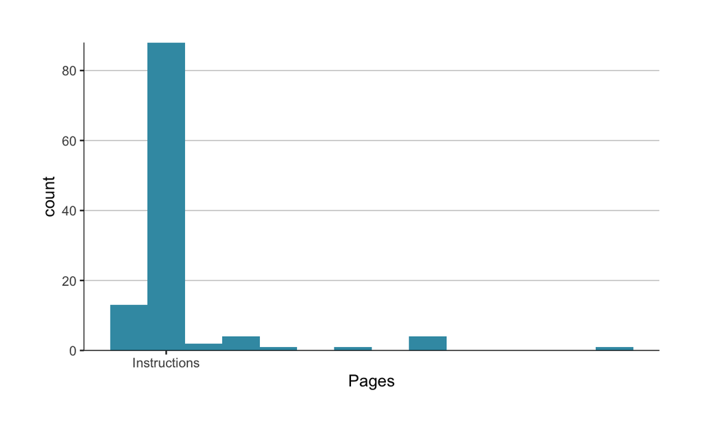

```r
ggplot(data[participant._index_in_pages < 20 & treated == FALSE],
       aes(x=participant._index_in_pages)) +
  geom_histogram(binwidth=1, fill = wes_palette("Zissou1")[1]) +
  scale_y_continuous(limits = c(0, NA), expand = c(0, 0)) +
  layout +
  labs(x = "Pages") +
  scale_x_continuous(breaks = c(2),
                     labels = c("Instructions"))
```

### by Browser Width

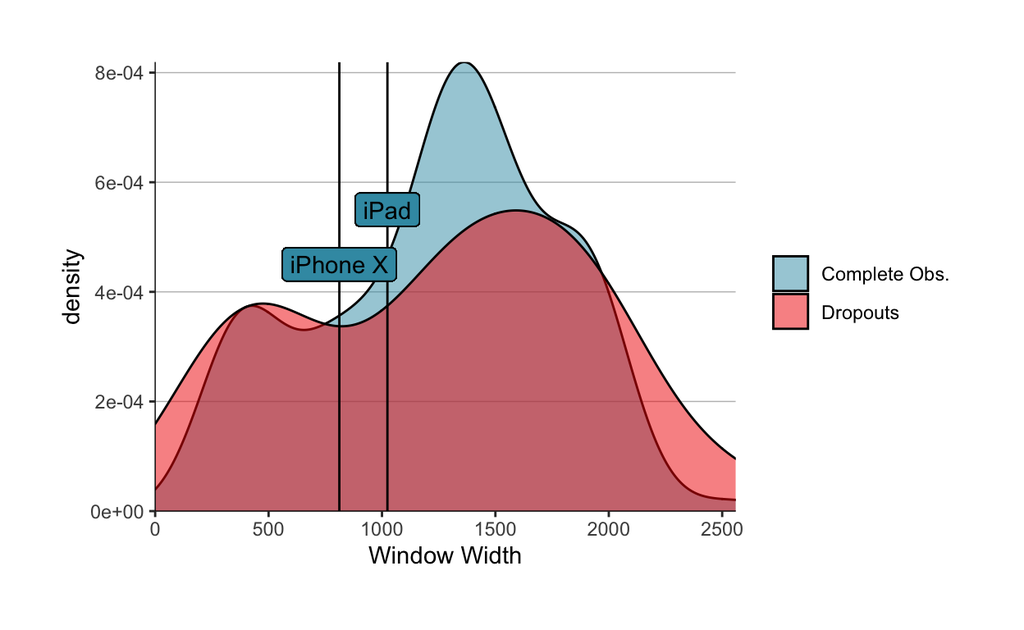

```r
ggplot(data[treated == FALSE],
       aes(x = Intro.1.player.window_width, fill = is_dropout)) +
  geom_density(alpha = 0.5) +
  scale_fill_manual(values = wes_palette("Zissou1")[c(1,5)],
                    labels = c("Complete Obs.", "Dropouts")) +
  scale_y_continuous(expand = c(0, NA)) +
  scale_x_continuous(limits = c(0, NA), expand = c(0, 0)) +
  geom_vline(xintercept = 812) +
  geom_vline(xintercept = 1024) +
  geom_label(label = "iPhone X",
             x = 812,
             y = 0.00045,
             show.legend = FALSE) +
  geom_label(label = "iPad",
             x = 1024,
             y = 0.00055,
             show.legend = FALSE) +
  layout +
  labs(x = "Window Width")
```

### by Browser Type

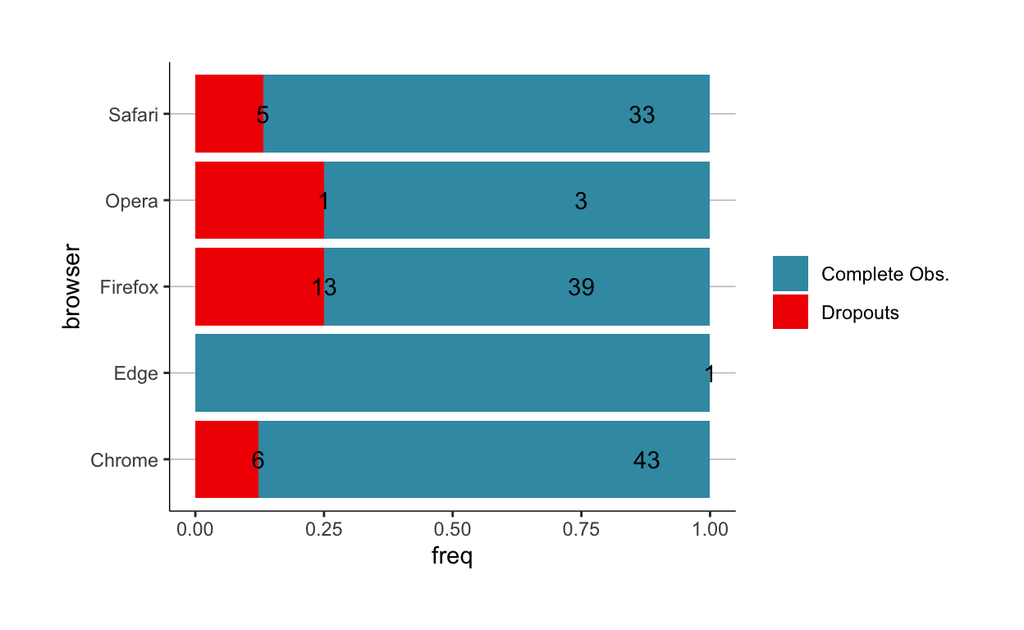

```r
data[,
     browser := str_replace_all(string = Intro.1.player.browser,
                                pattern = "\\W|\\d",
                                replacement = "")]
temp <- count(data[treated == FALSE & browser != ""], browser, is_dropout)
temp[,
     freq := n/sum(n),
     by = c("browser")]

ggplot(data = temp,
       aes(x=browser, y=freq, fill=is_dropout, label = n)) +
  geom_bar(stat="identity") +
  scale_fill_manual(values = wes_palette("Zissou1")[c(1,5)],
                    labels = c("Complete Obs.", "Dropouts")) +
  geom_text() +
  layout +
  coord_flip()
```

```r
# NROW(DT[participant._index_in_pages > 2 & participant._index_in_pages < 20])
data[is_dropout == TRUE & treated == FALSE, is_dropout %>% sum()]
```

```
[1] 114
```

```r
NROW(data[is_dropout == TRUE & treated == FALSE])
```

```
[1] 114
```

```r
NROW(data[is_dropout == FALSE & treated == FALSE])
```

```
[1] 119
```

## Time Spent

```r
timeSpent <- read.csv(file="../data/pilot/PageTimes-2021-05-25.csv",
                      stringsAsFactors = FALSE) %>% data.table()

timeSpent[,
          lag := shift(epoch_time, fill = NA, type = "lag"),
          by = participant_code]

timeSpent[,
          duration := epoch_time - lag,
          by = participant_code]

duration <- timeSpent[,
                      .(
                        session_code,
                        participant_code,
                        app_name,
                        page_name,
                        page_index,
                        page_submission = epoch_time,
                        time_spent = duration
                      )]

if(knitr::is_html_output()){
  duration %>%
  download_this(
        output_name = "timeSpent",
        output_extension = ".csv", # CSV output
        button_label = "Download PageTimes data",
        button_type = "default",
      )
}
```

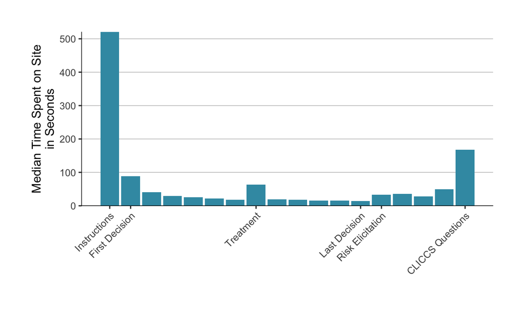

```r
col <- wes_palette("Zissou1")[1]

temp <- duration[,
                 median(time_spent),
                 by = c("page_name", "page_index")]

ggplot(temp,  aes(x=page_index, y = V1)) +
  geom_bar(stat="identity", fill = col) +
  scale_y_continuous(limits = c(0, NA), expand = c(0, 0)) +
  scale_x_continuous(breaks = c(2, 3, 9, 14, 15, 19),
                     labels = c("Instructions", "First Decision", "Treatment", "Last Decision", "Risk Elicitation", "CLICCS Questions")) +
  layout +
  theme(axis.text.x = element_text(angle = 45, hjust = 1)) +
  labs(y="Median Time Spent on Site\nin Seconds", x="")
```

oTree reports a timestamp for each page submission. Substracting these timestamps from one another, one can calculate the time spent on most pages, that is, all but the first and the last page. As a consequence, one can calculate the median time required to read the instructions and answer the comprehension questions: 521 seconds or more than 8 minutes. Aggregating the bars in the visualization above yields a measure of the time spent to complete the experiment of a litte more than 20 minutes. These numbers, however, also include dropouts.

```r
obs <- duration[page_index == 19, participant_code]
completionTime <- duration[participant_code %in% obs & page_index == 19, page_submission] - duration[participant_code %in% obs & page_index == 1, page_submission]

median(completionTime) %>% seconds_to_period()
ggplot(as.data.frame(completionTime),  aes(x=completionTime/60)) +
  geom_histogram(fill = wes_palette("Zissou1")[1]) +
  # scale_y_continuous(limits = c(0, NA), expand = c(0, 0)) +
  # scale_x_continuous(breaks = c(2, 3, 9, 14, 15, 19),
                     # labels = c("Instructions", "First Decision", "Treatment", "Last Decision", "Risk Elicitation", "CLICCS Questions")) +
  layout +
  theme(axis.text.x = element_text(angle = 45, hjust = 1)) +
  labs(y="Median Time Spent on Site\nin Seconds", x="")
```

[output not shown]

## Comprehension Questions

There were two comprehension checks, Q1 and Q2. This is what the distribution of wrong answers looks like, if one considers all 130 participants, who reached the third page, that is, all those who managed to answer the questions correctly, eventually.

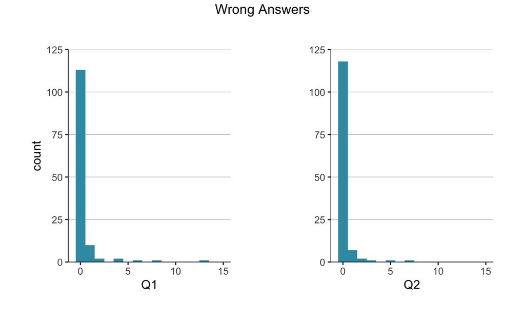

```r
temp <- data[participant._index_in_pages > 3 & treated == FALSE]
xmax <- temp[, max(Intro.1.player.wrong_answer_1, Intro.1.player.wrong_answer_2)] + 2

g1 <- ggplot(temp,
             aes(x=Intro.1.player.wrong_answer_1)) +
  geom_histogram(binwidth=1, fill = wes_palette("Zissou1")[1]) +
  scale_y_continuous(limits = c(0, 125), expand = c(0, 0)) +
  scale_x_continuous(limits = c(NA, xmax)) +
  layout +
  labs(x = "Q1")

g2 <- ggplot(temp,
             aes(x=Intro.1.player.wrong_answer_2)) +
  geom_histogram(binwidth=1, fill = wes_palette("Zissou1")[1]) +
  scale_y_continuous(limits = c(0, 125), expand = c(0, 0)) +
  scale_x_continuous(limits = c(NA, xmax)) +
  layout +
  labs(x = "Q2", y = "")

grid.arrange(
  g1,
  g2,
  nrow = 1,
  top = "Wrong Answers"
)
```

## Balance

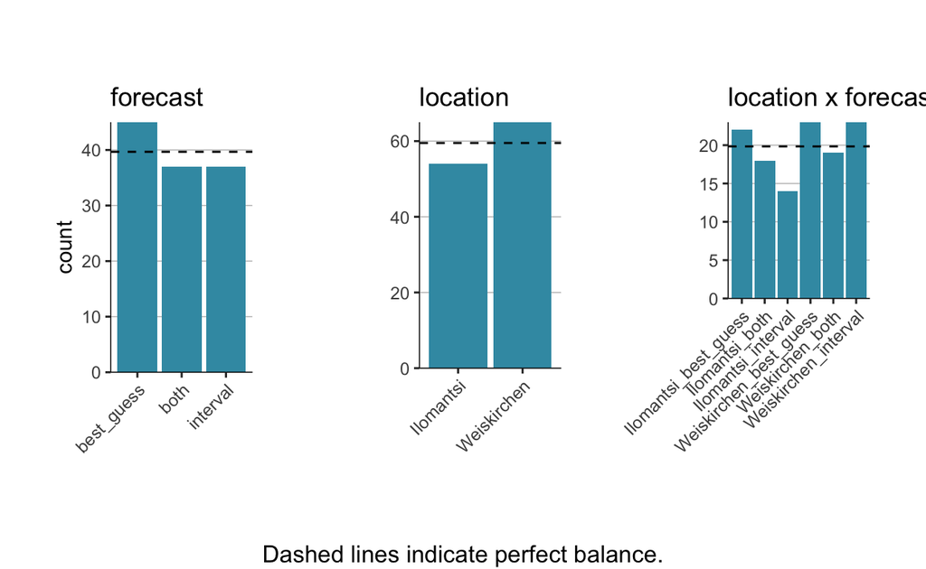

```r
temp <- data[participant._index_in_pages == 20 & treated == FALSE]
temp[, treatment := paste(location, forecast, sep ="_")]
len <- NROW(temp)

p1 <- ggplot(temp,
             aes(x=forecast)) +
  geom_bar(fill = col) +
  geom_hline(yintercept = len/3, lty = 2) +
  layout +
  theme(axis.text.x = element_text(angle = 45, hjust = 1)) +
  scale_y_continuous(limits = c(0, NA), expand = c(0, 0)) +
  labs(title="forecast",
       x="")

p2 <- ggplot(temp,
             aes(x=location)) +
  geom_bar(fill = col) +
  geom_hline(yintercept = len/2, lty = 2) +
  layout +
  theme(axis.text.x = element_text(angle = 45, hjust = 1)) +
  scale_y_continuous(limits = c(0, NA), expand = c(0, 0)) +
  labs(title="location",
       x="",
       y="")

p3 <- ggplot(temp,
             aes(x=treatment)) +
  geom_bar(fill = col) +
  geom_hline(yintercept = len/6, lty = 2) +
  layout +
  theme(axis.text.x = element_text(angle = 45, hjust = 1)) +
  scale_y_continuous(limits = c(0, NA), expand = c(0, 0)) +
  labs(title="location x forecast",
       y="",
       x="")

grid.arrange(
  p1,
  p2,
  p3,
  nrow = 1,
  top = "",
  bottom = "Dashed lines indicate perfect balance."
)
```

# Results

## Indices

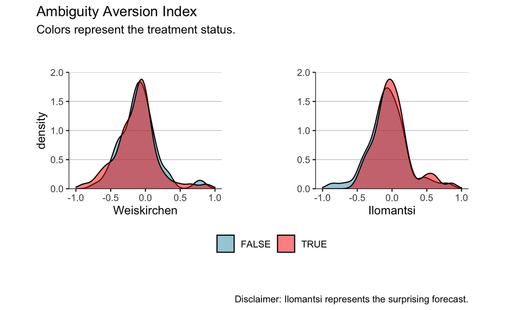

```r
p1 <- ggplot(data[participant._index_in_pages == 20 & location == "Weiskirchen"],
       aes(x = AAI, fill = treated)) +
  geom_density(alpha = 0.5) +
  scale_fill_manual(values = wes_palette("Zissou1")[c(1,5)]) +
  scale_y_continuous(expand = c(0, NA), limits = c(0,2)) +
  scale_x_continuous(limits = c(-1, 1)) +
  layout +
  labs(x = "Weiskirchen", fill = "Treated?")

p2 <- ggplot(data[participant._index_in_pages == 20 & location == "Ilomantsi"],
       aes(x = AAI, fill = treated)) +
  geom_density(alpha = 0.5) +
  scale_y_continuous(expand = c(0, NA), limits = c(0,2)) +
  scale_x_continuous(limits = c(-1, 1)) +
  scale_fill_manual(values = wes_palette("Zissou1")[c(1,5)]) +
  layout +
  labs(x = "Ilomantsi", fill = "Treated?", y = "")

patchwork <- p1 + p2 & theme(legend.position = "bottom")
patchwork <- patchwork + plot_layout(guides = "collect") + plot_annotation(
  title = "Ambiguity Aversion Index",
  subtitle = "Colors represent the treatment status.",
  caption = "Disclaimer: Ilomantsi represents the surprising forecast."
)
patchwork
```

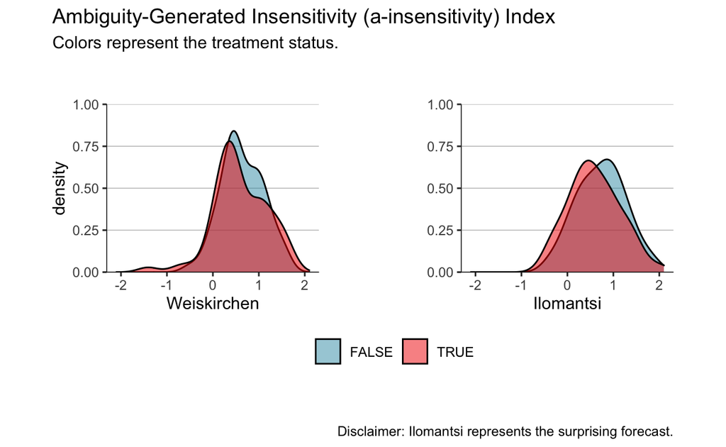

```r
p1 <- ggplot(data[participant._index_in_pages == 20 & location == "Weiskirchen"],
       aes(x = AGII, fill = treated)) +
  geom_density(alpha = 0.5) +
  scale_fill_manual(values = wes_palette("Zissou1")[c(1,5)]) +
  scale_y_continuous(expand = c(0, NA), limits = c(0,1)) +
  scale_x_continuous(limits = c(-2.1, 2.1)) +
  layout +
  labs(x = "Weiskirchen", fill = "Treated?")

p2 <- ggplot(data[participant._index_in_pages == 20 & location == "Ilomantsi"],
       aes(x = AGII, fill = treated)) +
  geom_density(alpha = 0.5) +
  scale_y_continuous(expand = c(0, NA), limits = c(0,1)) +
  scale_x_continuous(limits = c(-2.1, 2.1)) +
  scale_fill_manual(values = wes_palette("Zissou1")[c(1,5)]) +
  layout +
  labs(x = "Ilomantsi", fill = "Treated?", y = "")

patchwork <- p1 + p2 & theme(legend.position = "bottom")
patchwork <- patchwork + plot_layout(guides = "collect") + plot_annotation(
  title = "Ambiguity-Generated Insensitivity (a-insensitivity) Index",
  subtitle = "Colors represent the treatment status.",
  caption = "Disclaimer: Ilomantsi represents the surprising forecast."
)
patchwork
```

## Regressions

Some placeholder regressions:

```r
# names(data)
m1 <- lm(AAI ~ treated + location + treated*location, data = data[participant._index_in_pages == 20])
m2 <- lm(AGII ~ treated + location + treated*location, data = data[participant._index_in_pages == 20])
tab_model(m1, m2)
```

[output not shown]

Baillon, Aurélien, Zhenxing Huang, Asli Selim, and Peter P. Wakker. 2018. “Measuring Ambiguity Attitudes for All (Natural) Events.” *Econometrica* 86 (5): 1839–58. https://doi.org/https://doi.org/10.3982/ECTA14370.

[^1]: One should thus keep in mind to subset the data with `participant._index_in_pages == 20` if one wished to analyze the complete observations.
[^2]: Eventually, we should rename these variables to make them shorter. Names such as `MP[round]` and `event[round]` would be great.
[^3]: Eventually, we should write either a function or a nested loop.